# Sipros Data Analysis Workflow

- Uses The Following Objects:
  - SiprosDatabase: for loading and summarizing a protein database
  - SiprosSample: for loading each proteomics sample data
  - SiprosExperiment: for suumarizing multiple samples

## Step 1: Load Database

- We'll use matplotlib inline for any plots
- The SiprosDatabase object provides annotations of protein sequences
  - Taxonomic annotation based on BLASTp best hits
    - currently uses a parsed taxonomy file: protein ID - domain phyla class order family genus species
    - this may be changed in the future to allow import of a BLAST output or other sequence alignment such as kraken, diamond, or bowtie in order to assign cds or contig taxonomy
  - Functional annotation based on hmmscan of bactNOG database.
    - like the taxonomy annotation this uses a parsed file but may be expanded in the future to other types of annotation such as GO terms, SEED, KEGG ontology, or Pfams
- These annotations will be used to classify and count spectra, protein IDs, peptides, and enrichments

```python
%matplotlib inline
```

```python
from sip.SiprosDatabase import SiprosDatabase
```

```python
db = SiprosDatabase("db")
```

```python
db.load_faa("./AAhybrid.c100.faa")
```

```
Loading fasta file: ./AAhybrid.c100.faa
 - Total sequences: 38916
```

```python
db.load_taxonomy("./AAhybrid.taxonomy")
```

```
Loading taxonomy annotation file: ./AAhybrid.taxonomy
 - Annotated: 38235
 - Unannotated: 681
```

```python
db.load_bactNOG("./AAhybrid.bactNOG")
```

```
Loading bactNOG annotation file: ./AAhybrid.bactNOG
 - Annotated: 38450
 - Unannotated: 466
```

```
Counting NOG categories in database
	Category	Count
	A	0.0
	B	0.0
	C	4438.0
	D	340.0
	E	4448.0
	F	1947.0
	G	1797.0
	H	1201.0
	I	1623.0
	J	6374.0
	K	1455.0
	L	1629.0
	M	1430.0
	N	100.0
	O	2276.0
	P	2120.0
	Q	325.0
	R	2093.0
	S	3276.0
	T	590.0
	U	603.0
	V	156.0
	W	0.0
	X	0.0
	Y	0.0
	Z	0.0
	na	466.0
```

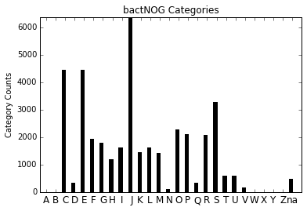

```python
db.nog_category_counts(plot="yes")
```

```
Counting taxa in database
 - Rank: order
 - Total taxa: 174
```

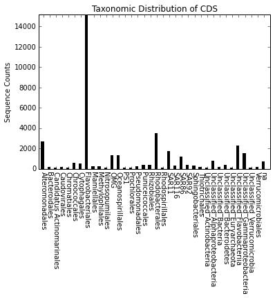

```python
db.taxonomy_counts('order',plot="yes",min_count=75)
```

## Step 2: Load Sample

## - The SiprosSample object loads and annotates peptide and protein identifications

[output not shown]

```python
from sip.SiprosSample import SiprosSample
```

```python
B1 = SiprosSample("B1", "amino_acids", 1, "MB", db, "./B1.pro.txt", "./B1.pep.txt")
```

```
SiprosSample Object Created:
	Name : B1
	Location : MB
	Treatment : amino_acids
	Timepoint : 1
Loading pro.txt file: ./B1.pro.txt
	Unique Protein IDs: 2606
	Total Protein IDs: 3378
Loading pep.txt file: ./B1.pep.txt
	Unique Spectra: 16077
	Total Spectra: 22208
	Total Peptide IDs: 18631
```

### Check the distribution of protein identifications by bactNOG category

- Some proteins are annotated with more than one category.
- In these cases counts are divided by the number of categories

```
bactNOG category counts in proteomics sample
	Category	Count
	A	0.0
	B	0.0
	C	319.0
	D	10.0
	E	325.0
	F	101.0
	G	225.0
	H	75.0
	I	85.0
	J	718.0
	K	158.0
	L	50.0
	M	98.0
	N	8.0
	O	241.0
	P	382.0
	Q	48.0
	R	135.0
	S	311.0
	T	17.0
	U	42.0
	V	5.0
	W	0.0
	X	0.0
	Y	0.0
	Z	0.0
	na	8.0
	u	3.0
```

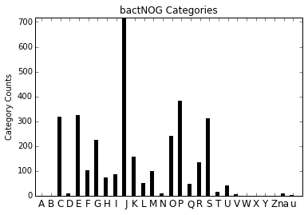

```python
B1.nog_category_counts(plot="yes", data="protein_counts")
```

```
bactNOG category counts in proteomics sample
	Category	Count
	A	0.0
	B	0.0
	C	2214.0
	D	93.0
	E	2205.5
	F	474.0
	G	1870.0
	H	425.5
	I	371.0
	J	5067.0
	K	1360.5
	L	224.0
	M	469.0
	N	46.0
	O	1493.0
	P	2573.5
	Q	541.0
	R	647.5
	S	1722.0
	T	127.833333333
	U	207.5
	V	17.0
	W	1.5
	X	0.0
	Y	0.0
	Z	0.0
	na	51.0
	u	6.66666666667
```

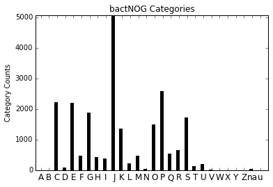

```python
B1.nog_category_counts(plot="yes", data="spectra_counts")
```

### Check the distribution of protein identifications by taxonomy

- 'na' are proteins that do not have a taxonomic assignment.
- 'u' are ambiguous protein identifications (1 peptide unique to the set + 1 shared.

```
Counting taxa in proteomics sample
 - Rank: order
 - Total taxa: 77
```

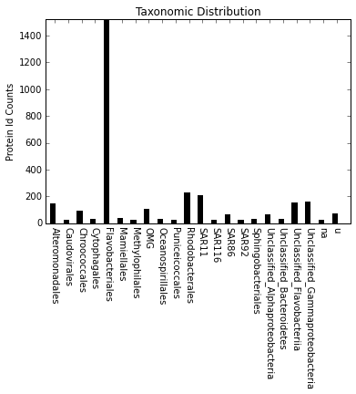

```python
B1.taxonomy_counts('order',min_count=20,plot="yes", data="protein_counts")
```

```
Counting taxa in proteomics sample
 - Rank: order
 - Total taxa: 77
```

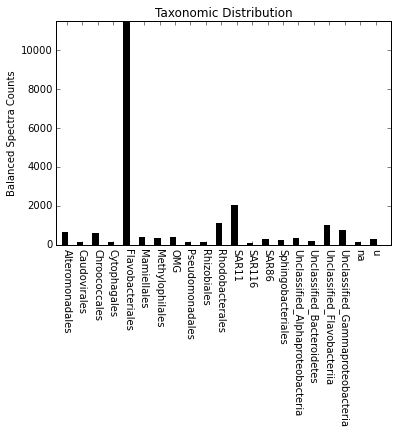

```python
B1.taxonomy_counts('order',min_count=100,plot="yes", data="spectra_counts")
```

```
plotting enrichment histogram
```

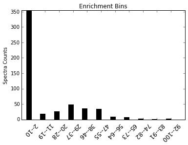

```python
B1.enrichment_counts (plot="yes")
```

## Step 3: Load Additional Samples

[output not shown]

```python
B2 = SiprosSample("B2", "amino_acids", 1, "MB", db, "./B2.pro.txt", "./B2.pep.txt")
```

```
SiprosSample Object Created:
	Name : B2
	Location : MB
	Treatment : amino_acids
	Timepoint : 1
Loading pro.txt file: ./B2.pro.txt
	Unique Protein IDs: 2819
	Total Protein IDs: 3613
Loading pep.txt file: ./B2.pep.txt
	Unique Spectra: 16496
	Total Spectra: 22669
	Total Peptide IDs: 19800
```

```python
B3 = SiprosSample("B3", "amino_acids", 1, "MB", db, "./B3.pro.txt", "./B3.pep.txt")
```

```
SiprosSample Object Created:
	Name : B3
	Location : MB
	Treatment : amino_acids
	Timepoint : 1
Loading pro.txt file: ./B3.pro.txt
	Unique Protein IDs: 2787
	Total Protein IDs: 3513
Loading pep.txt file: ./B3.pep.txt
	Unique Spectra: 17455
	Total Spectra: 25157
	Total Peptide IDs: 19668
```

```python
B4 = SiprosSample("B4", "amino_acids", 2, "MB", db, "./B4.pro.txt", "./B4.pep.txt")
```

```
SiprosSample Object Created:
	Name : B4
	Location : MB
	Treatment : amino_acids
	Timepoint : 2
Loading pro.txt file: ./B4.pro.txt
	Unique Protein IDs: 2218
	Total Protein IDs: 2885
Loading pep.txt file: ./B4.pep.txt
	Unique Spectra: 12158
	Total Spectra: 15959
	Total Peptide IDs: 15170
```

```python
B5 = SiprosSample("B5", "amino_acids", 2, "MB", db, "./B5.pro.txt", "./B5.pep.txt")
```

```
SiprosSample Object Created:
	Name : B5
	Location : MB
	Treatment : amino_acids
	Timepoint : 2
Loading pro.txt file: ./B5.pro.txt
	Unique Protein IDs: 2211
	Total Protein IDs: 2772
Loading pep.txt file: ./B5.pep.txt
	Unique Spectra: 13265
	Total Spectra: 17928
	Total Peptide IDs: 14992
```

```python
B6 = SiprosSample("B6", "amino_acids", 2, "MB", db, "./B6.pro.txt", "./B6.pep.txt")
```

```
SiprosSample Object Created:
	Name : B6
	Location : MB
	Treatment : amino_acids
	Timepoint : 2
Loading pro.txt file: ./B6.pro.txt
	Unique Protein IDs: 2328
	Total Protein IDs: 2860
Loading pep.txt file: ./B6.pep.txt
	Unique Spectra: 12898
	Total Spectra: 17510
	Total Peptide IDs: 15675
```

```python
OR1 = SiprosSample("OR1", "amino_acids", 1, "OR", db, "./T1.pro.txt", "./T1.pep.txt")
```

```
SiprosSample Object Created:
	Name : OR1
	Location : OR
	Treatment : amino_acids
	Timepoint : 1
Loading pro.txt file: ./T1.pro.txt
	Unique Protein IDs: 977
	Total Protein IDs: 1190
Loading pep.txt file: ./T1.pep.txt
	Unique Spectra: 5244
	Total Spectra: 6554
	Total Peptide IDs: 6441
```

```python
OR2 = SiprosSample("OR2", "amino_acids", 2, "OR", db, "./T2.pro.txt", "./T2.pep.txt")
```

```
SiprosSample Object Created:
	Name : OR2
	Location : OR
	Treatment : amino_acids
	Timepoint : 2
Loading pro.txt file: ./T2.pro.txt
	Unique Protein IDs: 948
	Total Protein IDs: 1147
Loading pep.txt file: ./T2.pep.txt
	Unique Spectra: 4913
	Total Spectra: 6374
	Total Peptide IDs: 6180
```

## Step 4: Use all Samples in a SiprosExperiment object

[output not shown]

```python
from sip.SiprosExperiment import SiprosExperiment
```

```python
AA1 = SiprosExperiment("AA1")
```

```python
AA1.add_sample(B1,B2,B3,OR1)
```

```
<>Sample count: 4
Name	Location	Treatment	TimePoint	NormFactor
B1	MB	amino_acids	1	0.862166786744
B2	MB	amino_acids	1	0.844633640655
B3	MB	amino_acids	1	0.761100290178
OR1	OR	amino_acids	1	2.92142203235
```

```
enrichment histogram for proteomics sample
cond: B1
cond: B2
cond: B3
cond: OR1
```

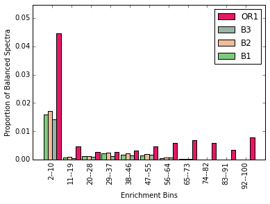

```python
AA1.plot_all_enrichments()
```

```python
AA2 = SiprosExperiment("AA2")
```

```python
AA2.add_sample(B4,B5,B6,OR2)
```

```
<>Sample count: 4
Name	Location	Treatment	TimePoint	NormFactor
B4	MB	amino_acids	2	0.904990914218
B5	MB	amino_acids	2	0.805597389558
B6	MB	amino_acids	2	0.824828669332
OR2	OR	amino_acids	2	2.26588484468
```

```
enrichment histogram for proteomics sample
cond: B4
cond: B5
cond: B6
cond: OR2
```

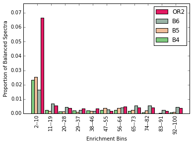

```python
AA2.plot_all_enrichments()
```